### Построение облака (поля) корреляции для исследования взаимосвязи между переменными

Для того чтобы составить первичное представление о взаимосвязи между переменными и при этом не строить много графиков, построим удобный график, представляющий из себя матрицу диаграмм рассеяния и их парные корреляции для соответствующих количественных переменных с диаграммами плотности на главной диагонали:

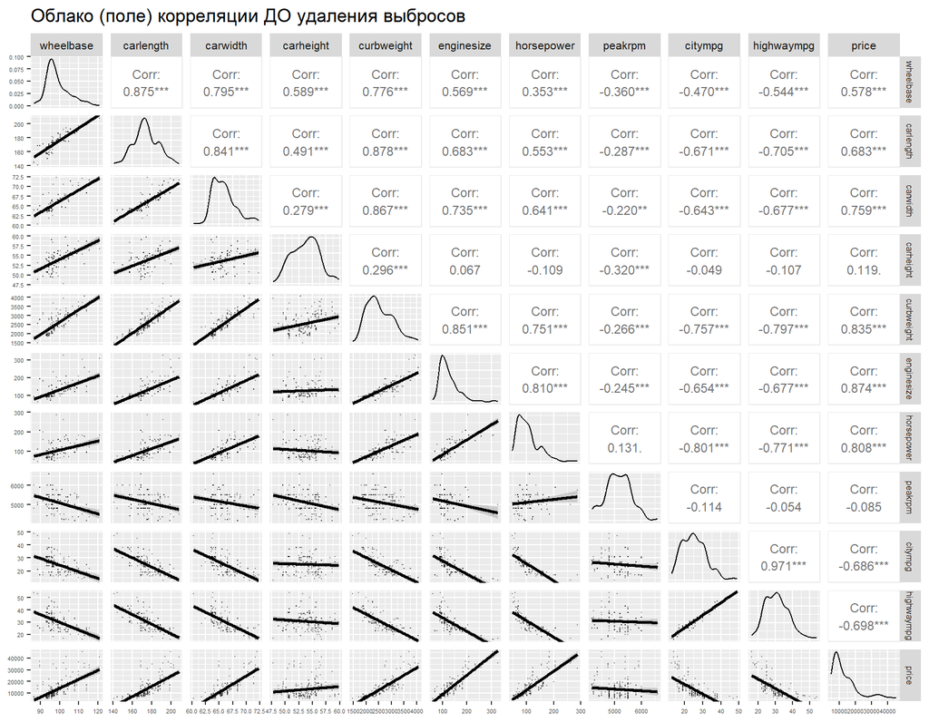

```r
ggpairs(df, title = 'Облако (поле) корреляции ДО удаления выбросов', lower = list(continuous = wrap("smooth", alpha = 0.3, size=0.1)),
upper = list(continuous = wrap("cor", size = 3), combo="blank")) + theme(axis.text = element_text(size = 4)) + theme(strip.text.x = element_text(size = 8),
           strip.text.y = element_text(size = 6))
```

Теперь посмотрим, как изменятся связи между переменными **после удаления выбросов** по правилу 1,5IQR:

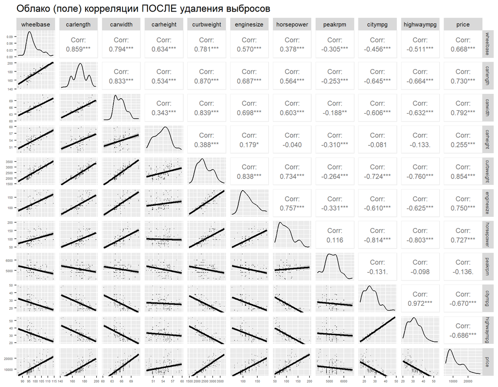

```r
ggpairs(df_new, title = 'Облако (поле) корреляции ПОСЛЕ удаления выбросов', lower = list(continuous = wrap("smooth", alpha = 0.3, size=0.1)),
upper = list(continuous = wrap("cor", size = 3), combo="blank")) + theme(axis.text = element_text(size = 4)) + theme(strip.text.x = element_text(size = 8),
           strip.text.y = element_text(size = 6))
```

После удаления выбросов ни одна из связей не сменилась на противоположную, что свидетельствует об отсутствие существенных выбросов, которые могли бы сильно влиять на направление зависимости между переменными.

Связь между зависимой переменной `price`(цена авто в $) и объясняющими переменными, отвечающих за габариты машины: `carlength` (длина машины (в футах)), `carwidth`(ширина машины (в футах)), `carheight` (высота машины (в футах)) возросли, коэффициент корреляции `carheight` (высота машины (в футах)) стал значимым. То же можно сказать и про связь между зависимой переменной и признаком `wheelbase`(расстояние между передним и задним колесами) – связь между ними усилилась после исключения аномальных значений.

### Построение матрицы парных коэффициентов корреляции

```r
kbl(caption = "Таблица 1. Корреляционная матрица ДО удаления выбросов, метод Пирсона", Cor_m1, booktabs = T, align = 'c') %>%
kable_classic(html_font = "Cambria", font_size = 13, full_width = F)
```

Таблица 1. Корреляционная матрица ДО удаления выбросов, метод Пирсона

|  | wheelbase | carlength | carwidth | carheight | curbweight | enginesize | horsepower | peakrpm | citympg | highwaympg | price |
| --- | --- | --- | --- | --- | --- | --- | --- | --- | --- | --- | --- |
| wheelbase | 1.00 | 0.87 | 0.80 | 0.59 | 0.78 | 0.57 | 0.35 | -0.36 | -0.47 | -0.54 | 0.58 |
| carlength | 0.87 | 1.00 | 0.84 | 0.49 | 0.88 | 0.68 | 0.55 | -0.29 | -0.67 | -0.70 | 0.68 |
| carwidth | 0.80 | 0.84 | 1.00 | 0.28 | 0.87 | 0.74 | 0.64 | -0.22 | -0.64 | -0.68 | 0.76 |
| carheight | 0.59 | 0.49 | 0.28 | 1.00 | 0.30 | 0.07 | -0.11 | -0.32 | -0.05 | -0.11 | 0.12 |
| curbweight | 0.78 | 0.88 | 0.87 | 0.30 | 1.00 | 0.85 | 0.75 | -0.27 | -0.76 | -0.80 | 0.84 |
| enginesize | 0.57 | 0.68 | 0.74 | 0.07 | 0.85 | 1.00 | 0.81 | -0.24 | -0.65 | -0.68 | 0.87 |
| horsepower | 0.35 | 0.55 | 0.64 | -0.11 | 0.75 | 0.81 | 1.00 | 0.13 | -0.80 | -0.77 | 0.81 |
| peakrpm | -0.36 | -0.29 | -0.22 | -0.32 | -0.27 | -0.24 | 0.13 | 1.00 | -0.11 | -0.05 | -0.09 |
| citympg | -0.47 | -0.67 | -0.64 | -0.05 | -0.76 | -0.65 | -0.80 | -0.11 | 1.00 | 0.97 | -0.69 |
| highwaympg | -0.54 | -0.70 | -0.68 | -0.11 | -0.80 | -0.68 | -0.77 | -0.05 | 0.97 | 1.00 | -0.70 |
| price | 0.58 | 0.68 | 0.76 | 0.12 | 0.84 | 0.87 | 0.81 | -0.09 | -0.69 | -0.70 | 1.00 |

Теперь построим матрицу парных коэффициентов после удаления выбросов, посмотрим, как изменились значения коэффициентов.

```r
kbl(caption = "Таблица 2. Корреляционная матрица ПОСЛЕ удаления выбросов, метод Пирсона", Cor_m2, booktabs = T, align = 'c') %>%
kable_classic(html_font = "Cambria", font_size = 13, full_width = F)
```

Таблица 2. Корреляционная матрица ПОСЛЕ удаления выбросов, метод Пирсона

|  | wheelbase | carlength | carwidth | carheight | curbweight | enginesize | horsepower | peakrpm | citympg | highwaympg | price |
| --- | --- | --- | --- | --- | --- | --- | --- | --- | --- | --- | --- |
| wheelbase | 1.00 | 0.86 | 0.79 | 0.63 | 0.78 | 0.57 | 0.38 | -0.30 | -0.46 | -0.51 | 0.67 |
| carlength | 0.86 | 1.00 | 0.83 | 0.53 | 0.87 | 0.69 | 0.56 | -0.25 | -0.65 | -0.66 | 0.73 |
| carwidth | 0.79 | 0.83 | 1.00 | 0.34 | 0.84 | 0.70 | 0.60 | -0.19 | -0.61 | -0.63 | 0.79 |
| carheight | 0.63 | 0.53 | 0.34 | 1.00 | 0.39 | 0.18 | -0.04 | -0.31 | -0.08 | -0.13 | 0.25 |
| curbweight | 0.78 | 0.87 | 0.84 | 0.39 | 1.00 | 0.84 | 0.73 | -0.26 | -0.72 | -0.76 | 0.85 |
| enginesize | 0.57 | 0.69 | 0.70 | 0.18 | 0.84 | 1.00 | 0.76 | -0.33 | -0.61 | -0.63 | 0.75 |
| horsepower | 0.38 | 0.56 | 0.60 | -0.04 | 0.73 | 0.76 | 1.00 | 0.12 | -0.81 | -0.80 | 0.73 |
| peakrpm | -0.30 | -0.25 | -0.19 | -0.31 | -0.26 | -0.33 | 0.12 | 1.00 | -0.13 | -0.10 | -0.14 |
| citympg | -0.46 | -0.65 | -0.61 | -0.08 | -0.72 | -0.61 | -0.81 | -0.13 | 1.00 | 0.97 | -0.67 |
| highwaympg | -0.51 | -0.66 | -0.63 | -0.13 | -0.76 | -0.63 | -0.80 | -0.10 | 0.97 | 1.00 | -0.69 |
| price | 0.67 | 0.73 | 0.79 | 0.25 | 0.85 | 0.75 | 0.73 | -0.14 | -0.67 | -0.69 | 1.00 |

```r
corrplot.mixed(cor(df_new), lower.col = 'black', upper = 'ellipse', number.cex = 0.7, tl.pos = 'lt', tl.srt = 45,
               tl.cex = 0.7, tl.col = 'black')
```

[output not shown]

Удаление выбросов кардинально не изменило значение коэффициентов корреляции. Отметим только то, что теперь взаимосвязь между ценой машины и ее высотой прямая и слабая (коэффициент корреляции поменял значение с 0,12 до 0,25), между ценой машины и объемом двигателя, лошадиными силами - прямая взаимосвязь средней силы ( коэффициенты корреляции поменяли значения с 0,87 на 0,75 и с 0,81 на 0,73, соответственно).

Проверим значимость коэффициентов корреляции до и после удаления выбросов.

Сначала найдем p-value для коэффициентов корреляции до удаления выбросов.

```r
Cor_m3 <- rcorr(as.matrix(df), type = "pearson")
kbl(caption = "Таблица 3. Корреляционная матрица, метод Пирсона, p-values", Cor_m3$P, booktabs = T) %>%
  kable_classic(html_font = "Cambria", font_size = 12, full_width = F)
```

Таблица 3. Корреляционная матрица, метод Пирсона, p-values

|  | wheelbase | carlength | carwidth | carheight | curbweight | enginesize | horsepower | peakrpm | citympg | highwaympg | price |
| --- | --- | --- | --- | --- | --- | --- | --- | --- | --- | --- | --- |
| wheelbase | NA | 0.00e+00 | 0.0000000 | 0.0000000 | 0.00e+00 | 0.0000000 | 0.0000002 | 0.0000001 | 0.0000000 | 0.0000000 | 0.0000000 |
| carlength | 0e+00 | NA | 0.0000000 | 0.0000000 | 0.00e+00 | 0.0000000 | 0.0000000 | 0.0000297 | 0.0000000 | 0.0000000 | 0.0000000 |
| carwidth | 0e+00 | 0.00e+00 | NA | 0.0000503 | 0.00e+00 | 0.0000000 | 0.0000000 | 0.0015256 | 0.0000000 | 0.0000000 | 0.0000000 |
| carheight | 0e+00 | 0.00e+00 | 0.0000503 | NA | 1.69e-05 | 0.3387566 | 0.1204479 | 0.0000028 | 0.4885825 | 0.1254830 | 0.0883283 |
| curbweight | 0e+00 | 0.00e+00 | 0.0000000 | 0.0000169 | NA | 0.0000000 | 0.0000000 | 0.0001140 | 0.0000000 | 0.0000000 | 0.0000000 |
| enginesize | 0e+00 | 0.00e+00 | 0.0000000 | 0.3387566 | 0.00e+00 | NA | 0.0000000 | 0.0004071 | 0.0000000 | 0.0000000 | 0.0000000 |
| horsepower | 2e-07 | 0.00e+00 | 0.0000000 | 0.1204479 | 0.00e+00 | 0.0000000 | NA | 0.0610288 | 0.0000000 | 0.0000000 | 0.0000000 |
| peakrpm | 1e-07 | 2.97e-05 | 0.0015256 | 0.0000028 | 1.14e-04 | 0.0004071 | 0.0610288 | NA | 0.1050146 | 0.4395726 | 0.2241412 |
| citympg | 0e+00 | 0.00e+00 | 0.0000000 | 0.4885825 | 0.00e+00 | 0.0000000 | 0.0000000 | 0.1050146 | NA | 0.0000000 | 0.0000000 |
| highwaympg | 0e+00 | 0.00e+00 | 0.0000000 | 0.1254830 | 0.00e+00 | 0.0000000 | 0.0000000 | 0.4395726 | 0.0000000 | NA | 0.0000000 |
| price | 0e+00 | 0.00e+00 | 0.0000000 | 0.0883283 | 0.00e+00 | 0.0000000 | 0.0000000 | 0.2241412 | 0.0000000 | 0.0000000 | NA |

Комбинируем оценку корреляционной матрицы с результатами тестов на значимость:

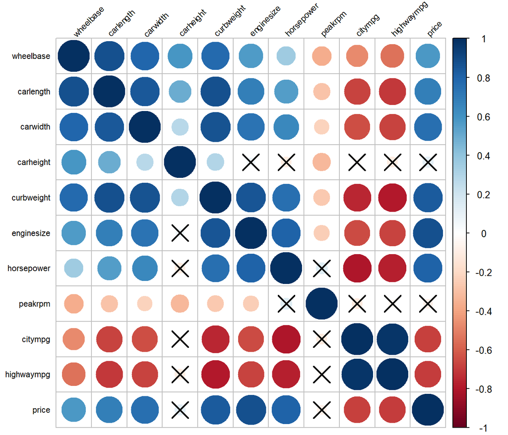

```r
res <- cor.mtest(df, conf.level = 0.95)
corrplot(cor(df), p.mat = res$p, sig.level = 0.05, tl.col = "black", tl.srt = 45, tl.cex = 0.7)
```

Необходимо отметить, что для данных **до удаления** выбросов девять коэффициентов корреляции являются **не значимыми**, то есть их p-value больше 0,05:

1. высота машины и объем двигателя;
2. высота машины и лошадиные силы;
3. высота машины и миль на галлон топлива, потребляемого при движении по городу;
4. высота машины и миль на галлон топлива, потребляемого при движении по шоссе;
5. высота машины и ее цена;
6. лошадиные силы и количество оборотов, при которых достигается максимальная мощность двигателя;
7. количество оборотов, при которых достигается максимальная мощность двигателя, и миль на галлон топлива, потребляемого при движении по городу;
8. количество оборотов, при которых достигается максимальная мощность двигателя, и миль на галлон топлива, потребляемого при движении по шоссе;
9. количество оборотов, при которых достигается максимальная мощность двигателя, и цена машины.

Аналогичные действия проделаем с данными **после удаления выбросов**:

```r
Cor_m4 <- rcorr(as.matrix(df_new), type = "pearson")
kbl(caption = "Таблица 2. Корреляционная матрица, метод Пирсона, p-values", Cor_m4$P, booktabs = T) %>%
  kable_classic(html_font = "Cambria", font_size = 13, full_width = F)
```

Таблица 2. Корреляционная матрица, метод Пирсона, p-values

|  | wheelbase | carlength | carwidth | carheight | curbweight | enginesize | horsepower | peakrpm | citympg | highwaympg | price |
| --- | --- | --- | --- | --- | --- | --- | --- | --- | --- | --- | --- |
| wheelbase | NA | 0.0000000 | 0.0000000 | 0.0000000 | 0.0000000 | 0.0000000 | 0.0000001 | 0.0000191 | 0.0000000 | 0.0000000 | 0.0000000 |
| carlength | 0.00e+00 | NA | 0.0000000 | 0.0000000 | 0.0000000 | 0.0000000 | 0.0000000 | 0.0004334 | 0.0000000 | 0.0000000 | 0.0000000 |
| carwidth | 0.00e+00 | 0.0000000 | NA | 0.0000013 | 0.0000000 | 0.0000000 | 0.0000000 | 0.0095114 | 0.0000000 | 0.0000000 | 0.0000000 |
| carheight | 0.00e+00 | 0.0000000 | 0.0000013 | NA | 0.0000000 | 0.0135139 | 0.5848512 | 0.0000133 | 0.2688028 | 0.0669463 | 0.0003936 |
| curbweight | 0.00e+00 | 0.0000000 | 0.0000000 | 0.0000000 | NA | 0.0000000 | 0.0000000 | 0.0002316 | 0.0000000 | 0.0000000 | 0.0000000 |
| enginesize | 0.00e+00 | 0.0000000 | 0.0000000 | 0.0135139 | 0.0000000 | NA | 0.0000000 | 0.0000031 | 0.0000000 | 0.0000000 | 0.0000000 |
| horsepower | 1.00e-07 | 0.0000000 | 0.0000000 | 0.5848512 | 0.0000000 | 0.0000000 | NA | 0.1120695 | 0.0000000 | 0.0000000 | 0.0000000 |
| peakrpm | 1.91e-05 | 0.0004334 | 0.0095114 | 0.0000133 | 0.0002316 | 0.0000031 | 0.1120695 | NA | 0.0709768 | 0.1797147 | 0.0609865 |
| citympg | 0.00e+00 | 0.0000000 | 0.0000000 | 0.2688028 | 0.0000000 | 0.0000000 | 0.0000000 | 0.0709768 | NA | 0.0000000 | 0.0000000 |
| highwaympg | 0.00e+00 | 0.0000000 | 0.0000000 | 0.0669463 | 0.0000000 | 0.0000000 | 0.0000000 | 0.1797147 | 0.0000000 | NA | 0.0000000 |
| price | 0.00e+00 | 0.0000000 | 0.0000000 | 0.0003936 | 0.0000000 | 0.0000000 | 0.0000000 | 0.0609865 | 0.0000000 | 0.0000000 | NA |

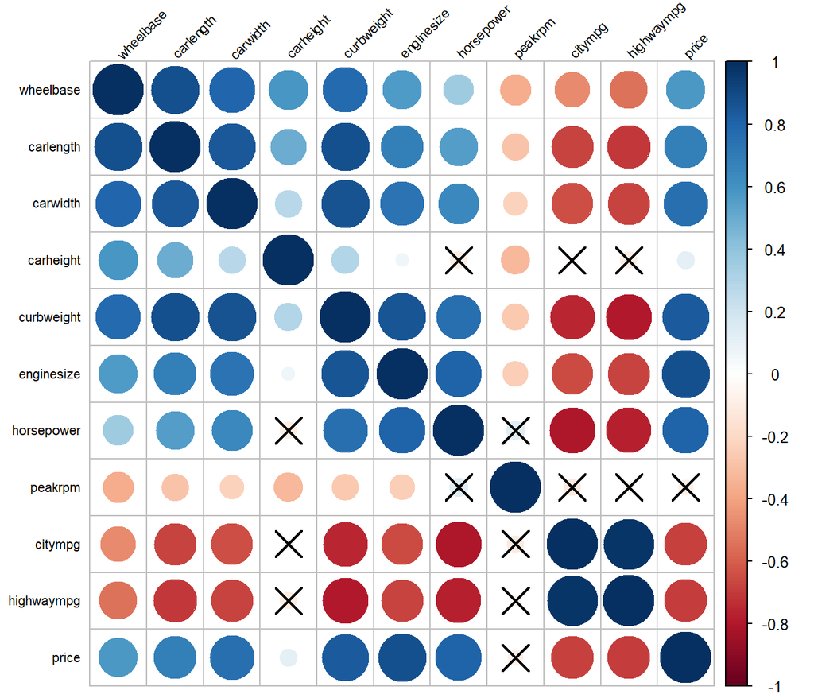

```r
res <- cor.mtest(df_new, conf.level = 0.95)
corrplot(cor(df), p.mat = res$p, sig.level = 0.05, tl.col = "black", tl.srt = 45, tl.cex = 0.7)
```

После удаления выбросов всего семь коэффициентов корреляции незначимы, это:

1. высота машины и лошадиные силы;
2. высота машины и миль на галлон топлива, потребляемого при движении по городу;
3. высота машины и миль на галлон топлива, потребляемого при движении по шоссе;
4. лошадиные силы и количество оборотов, при которых достигается максимальная мощность двигателя;
5. количество оборотов, при которых достигается максимальная мощность двигателя, и миль на галлон топлива, потребляемого при движении по городу;
6. количество оборотов, при которых достигается максимальная мощность двигателя, и миль на галлон топлива, потребляемого при движении по шоссе;
7. количество оборотов, при которых достигается максимальная мощность двигателя, и цена машины.

Коэффициенты корреляции высоты машины и объем двигателя, а также высоты машины и ее цены стали значимыми после удаления выбросов.

### Построение доверительных интервалов для значимых коэффициентов корреляции

После удаления выбросов значимыми коэффициентами корреляции оказалось очень много, поэтому построим доверительные интервалы только для самых значимых коэффициентов корреляции (которые принимают значения по модулю больше 0,8), то есть между следующими переменными:

1. `carlength` и `wheelbase` (0,86)
2. `carwidth` и `carlength` (0,83)
3. `curbweight` и `carlength` (0,87)
4. `curbweight` и `carwidth` (0,83)
5. `enginesize` и `curbweight` (0,83)
6. `price` и `curbweight` (0,85)
7. `citympg` и `horsepower` (**-0,81**)
8. `highwaympg` и `horsepower` (-0,80)
9. `highwaympg` и `citympg` (0,97)

Посчитаем доверительные интервалы для коэффициентов корреляции с помощью преобразования Фишера, используя следующие преобразования:

$$Z = 0,5*ln(\frac{1+r}{1-r})$$

$$SE_Z = \frac{1}{\sqrt{n-3}}$$

$$Z \in (Z-Z_{1-\frac{\alpha}{2}} * SE_Z;
Z+Z_{1-\frac{\alpha}{2}} * SE_Z)$$

Далее нужны сделать обратное преобразование:

$$r \in
(\frac{exp^{2Z_{min}}-1}{exp^{2Z_{min}}+1};
\frac{exp^{2Z_{max}}-1}{exp^{2Z_{max}}+1})$$

Первая взаимосвязь (`carlength` и `wheelbase`):

```r
cor.test(df_new$carlength, df_new$wheelbase, method = "pearson")
```

```
##
##  Pearson's product-moment correlation
##
## data:  df_new$carlength and df_new$wheelbase
## t = 23.034, df = 188, p-value < 2.2e-16
## alternative hypothesis: true correlation is not equal to 0
## 95 percent confidence interval:
##  0.8168440 0.8924656
## sample estimates:
##       cor
## 0.8592799
```

- С помощью метода Пирсона мы видим следующее :
  - t - значение тестовой статистики (t = 23,034)
  - p-value - это уровень значимости тестовой статистики (p-value < 2.2e-16).
  - Альтернативная гипотеза - истинная корреляция не равна 0.
  - Доверительный интервал: (0,8168 ; 0,8925). Существует вероятность 95%, что доверительный интервал (0,8168 ; 0,8925) содержит истинный коэффициент корреляции между длиной машины и расстоянием между передними и задними колесами автомобиля.

    То есть существует только 5% вероятность того, что истинный коэффициент корреляции между длиной машины и расстоянием между передними и задними колесами автомобиля меньше 0,8168 или больше 0,8925

Вторая взаимосвязь:

```r
cor.test(df_new$carlength, df_new$carwidth, method = "pearson")
```

```
##
##  Pearson's product-moment correlation
##
## data:  df_new$carlength and df_new$carwidth
## t = 20.606, df = 188, p-value < 2.2e-16
## alternative hypothesis: true correlation is not equal to 0
## 95 percent confidence interval:
##  0.7829758 0.8715926
## sample estimates:
##       cor
## 0.8325354
```

- Доверительный интервал: (0,783 ; 0,8716). Существует вероятность 95%, что доверительный интервал (0,783 ; 0,8716) содержит истинный коэффициент корреляции между длиной и шириной машины.
- То есть существует только 5% вероятность того, что истинный коэффициент корреляции между длиной и шириной машины меньше 0,783 или больше 0,8716.

Третья взаимосвязь:

```r
cor.test(df_new$carlength, df_new$curbweight, method = "pearson")
```

```
##
##  Pearson's product-moment correlation
##
## data:  df_new$carlength and df_new$curbweight
## t = 24.188, df = 188, p-value < 2.2e-16
## alternative hypothesis: true correlation is not equal to 0
## 95 percent confidence interval:
##  0.8304360 0.9007523
## sample estimates:
##       cor
## 0.8699481
```

- Доверительный интервал: (0,8304 ; 0,9008). Существует вероятность 95%, что доверительный интервал (0,8304 ; 0,9008) содержит истинный коэффициент корреляции между длиной и весом машины.

  То есть существует только 5% вероятность того, что истинный коэффициент корреляции между длиной и весом машины меньше 0,8304 или больше 0,9008.

Четвертая взаимосвязь:

```r
cor.test(df_new$carwidth, df_new$curbweight, method = "pearson")
```

```
##
##  Pearson's product-moment correlation
##
## data:  df_new$carwidth and df_new$curbweight
## t = 21.102, df = 188, p-value < 2.2e-16
## alternative hypothesis: true correlation is not equal to 0
## 95 percent confidence interval:
##  0.7905522 0.8762900
## sample estimates:
##       cor
## 0.8385383
```

- Доверительный интервал: (0,7906 ; 0,8763). Существует вероятность 95%, что доверительный интервал (0,7906 ; 0,8763) содержит истинный коэффициент корреляции между шириной и весом машины.

  То есть существует только 5% вероятность того, что истинный коэффициент корреляции между шириной и весом машины меньше 0,7906 или больше 0,8763.

Пятая взаимосвязь:

```r
cor.test(df_new$enginesize, df_new$curbweight, method = "pearson")
```

```
##
##  Pearson's product-moment correlation
##
## data:  df_new$enginesize and df_new$curbweight
## t = 21.047, df = 188, p-value < 2.2e-16
## alternative hypothesis: true correlation is not equal to 0
## 95 percent confidence interval:
##  0.7897224 0.8757764
## sample estimates:
##       cor
## 0.8378815
```

- Доверительный интервал: (0,7897 ; 0,8758). Существует вероятность 95%, что доверительный интервал (0,7897 ; 0,8758) содержит истинный коэффициент корреляции между объемом двигателя и весом машины.

  То есть существует только 5% вероятность того, что истинный коэффициент корреляции между объемом двигателя и весом машины меньше 0,7897 или больше 0,8758.

Шестая взаимосвязь:

```r
cor.test(df_new$price, df_new$curbweight, method = "pearson")
```

```
##
##  Pearson's product-moment correlation
##
## data:  df_new$price and df_new$curbweight
## t = 22.502, df = 188, p-value < 2.2e-16
## alternative hypothesis: true correlation is not equal to 0
## 95 percent confidence interval:
##  0.8100728 0.8883183
## sample estimates:
##       cor
## 0.8539514
```

Седьмая взаимосвязь:

```r
cor.test(df_new$citympg, df_new$horsepower, method = "pearson")
```

```
##
##  Pearson's product-moment correlation
##
## data:  df_new$citympg and df_new$horsepower
## t = -19.182, df = 188, p-value < 2.2e-16
## alternative hypothesis: true correlation is not equal to 0
## 95 percent confidence interval:
##  -0.8566823 -0.7590999
## sample estimates:
##        cor
## -0.8135416
```

- Доверительный интервал: (-0,8567 ; -0,7591). Существует вероятность 95%, что доверительный интервал (-0,8567 ; -0,7591) содержит истинный коэффициент корреляции между милями на галлон топлива, потребляемого при движении по городу и лошадиными силами.

  То есть существует только 5% вероятность того, что истинный коэффициент корреляции между милями на галлон топлива, потребляемого при движении по городу и лошадиными силами меньше -0,8567 или больше -0,7591.

Восьмая взаимосвязь:

```r
cor.test(df_new$highwaympg, df_new$horsepower, method = "pearson")
```

```
##
##  Pearson's product-moment correlation
##
## data:  df_new$highwaympg and df_new$horsepower
## t = -18.447, df = 188, p-value < 2.2e-16
## alternative hypothesis: true correlation is not equal to 0
## 95 percent confidence interval:
##  -0.8480483 -0.7453935
## sample estimates:
##        cor
## -0.8025851
```

- Доверительный интервал: (-0,848 ; -0,7454). Существует вероятность 95%, что доверительный интервал (-0,848 ; -0,7454) содержит истинный коэффициент корреляции между милями на галлон топлива, потребляемого при движении по шоссе и лошадиными силами.

  То есть существует только 5% вероятность того, что истинный коэффициент корреляции между милями на галлон топлива, потребляемого при движении по шоссе и лошадиными силами меньше -0,848 или больше -0,7454.

Девятая взаимосвязь:

```r
cor.test(df_new$highwaympg, df_new$citympg, method = "pearson")
```

```
##
##  Pearson's product-moment correlation
##
## data:  df_new$highwaympg and df_new$citympg
## t = 56.754, df = 188, p-value < 2.2e-16
## alternative hypothesis: true correlation is not equal to 0
## 95 percent confidence interval:
##  0.9629233 0.9789310
## sample estimates:
##       cor
## 0.9720347
```

- Доверительный интервал: (0,9629 ; 0,9789). Существует вероятность 95%, что доверительный интервал (0,9629 ; 0,9789) содержит истинный коэффициент корреляции между милями на галлон топлива, потребляемого при движении по шоссе и по городу.

  То есть существует только 5% вероятность того, что истинный коэффициент корреляции между милями на галлон топлива, потребляемого при движении по шоссе и по городу меньше 0,9629 или больше 0,9789.

### Построение и интерпретация матрицы частных коэффициентов корреляции, построение доверительных интервалов, проверка значимости коэффициентов корреляции.

Частные коэффициенты корреляции. Построим матрицу частных коэффициентов корреляции ПОСЛЕ удаления выбросов:

```r
cor_p <- pcor(scale(df_new))
colnames(cor_p$estimate) <- names(df_new)
rownames(cor_p$estimate) <- names(df_new)

kbl(caption = "Таблица 4.1. Матрица частных коэффициентов корреляции", cor_p$estimate, booktabs = T) %>%
  kable_classic(html_font = "Cambria", font_size = 12, full_width = F)
```

Таблица 4.1. Матрица частных коэффициентов корреляции

|  | wheelbase | carlength | carwidth | carheight | curbweight | enginesize | horsepower | peakrpm | citympg | highwaympg | price |
| --- | --- | --- | --- | --- | --- | --- | --- | --- | --- | --- | --- |
| wheelbase | 1.0000000 | 0.3790338 | 0.3165284 | 0.3334944 | 0.1231336 | -0.0266847 | -0.1756872 | 0.0089047 | 0.2018711 | -0.1873117 | 0.1102919 |
| carlength | 0.3790338 | 1.0000000 | 0.2569590 | 0.2475964 | 0.2963110 | 0.0207044 | -0.0182549 | -0.0239233 | -0.3125833 | 0.2209909 | -0.1477434 |
| carwidth | 0.3165284 | 0.2569590 | 1.0000000 | -0.2481626 | 0.1085107 | 0.0387524 | -0.0039307 | 0.0793492 | 0.0142079 | 0.0147537 | 0.2512903 |
| carheight | 0.3334944 | 0.2475964 | -0.2481626 | 1.0000000 | 0.1089953 | -0.1011095 | -0.1466986 | -0.0306225 | 0.0896479 | -0.0502678 | -0.0048496 |
| curbweight | 0.1231336 | 0.2963110 | 0.1085107 | 0.1089953 | 1.0000000 | 0.3322019 | 0.1497025 | -0.1899784 | 0.1437293 | -0.2593379 | 0.3340779 |
| enginesize | -0.0266847 | 0.0207044 | 0.0387524 | -0.1011095 | 0.3322019 | 1.0000000 | 0.4795468 | -0.4281877 | 0.0230953 | 0.0675604 | 0.0180597 |
| horsepower | -0.1756872 | -0.0182549 | -0.0039307 | -0.1466986 | 0.1497025 | 0.4795468 | 1.0000000 | 0.3843399 | -0.1557648 | -0.0393367 | 0.1866300 |
| peakrpm | 0.0089047 | -0.0239233 | 0.0793492 | -0.0306225 | -0.1899784 | -0.4281877 | 0.3843399 | 1.0000000 | -0.0353330 | -0.0399700 | 0.0435388 |
| citympg | 0.2018711 | -0.3125833 | 0.0142079 | 0.0896479 | 0.1437293 | 0.0230953 | -0.1557648 | -0.0353330 | 1.0000000 | 0.9057053 | -0.0847984 |
| highwaympg | -0.1873117 | 0.2209909 | 0.0147537 | -0.0502678 | -0.2593379 | 0.0675604 | -0.0393367 | -0.0399700 | 0.9057053 | 1.0000000 | 0.0989336 |
| price | 0.1102919 | -0.1477434 | 0.2512903 | -0.0048496 | 0.3340779 | 0.0180597 | 0.1866300 | 0.0435388 | -0.0847984 | 0.0989336 | 1.0000000 |

Также изобразим в более наглядном виде:

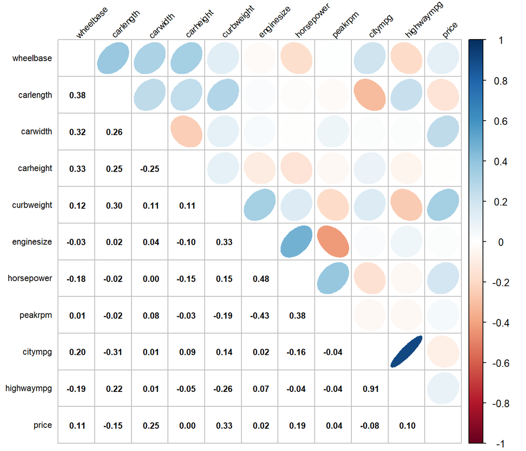

```r
corrplot.mixed(round(cor_p$estimate, 4), lower.col = 'black', upper = 'ellipse', number.cex = 0.7, tl.pos = 'lt', tl.cex = 0.7, tl.col = 'black',  tl.srt = 45)
```

По матрице видим, что сильных взаимосвязей практически нет,но мы опишем наиболее интересные:

    ```r
    colnames(cor_p$p.value) <- names(df_new)
    rownames(cor_p$p.value) <- names(df_new)
    kbl(caption = "Таблица 4.2. Матрица частных коэффициентов корреляции, p-values",
    cor_p$p.value, booktabs = T) %>% kable_classic(html_font = "Cambria", font_size = 12, full_width = F)
    ```

    Таблица 4.2. Матрица частных коэффициентов корреляции, p-values

    |  | wheelbase | carlength | carwidth | carheight | curbweight | enginesize | horsepower | peakrpm | citympg | highwaympg | price |
    | --- | --- | --- | --- | --- | --- | --- | --- | --- | --- | --- | --- |
    | wheelbase | 0.0000000 | 0.0000001 | 0.0000142 | 0.0000045 | 0.0986555 | 0.7214046 | 0.0179968 | 0.9052973 | 0.0064263 | 0.0115714 | 0.1393920 |
    | carlength | 0.0000001 | 0.0000000 | 0.0004796 | 0.0007781 | 0.0000512 | 0.7820493 | 0.8072980 | 0.7492175 | 0.0000183 | 0.0027936 | 0.0471646 |
    | carwidth | 0.0000142 | 0.0004796 | 0.0000000 | 0.0007560 | 0.1459338 | 0.6044985 | 0.9581179 | 0.2883206 | 0.8494399 | 0.8437290 | 0.0006443 |
    | carheight | 0.0000045 | 0.0007781 | 0.0007560 | 0.0000000 | 0.1441313 | 0.1756286 | 0.0487664 | 0.6823744 | 0.2300806 | 0.5015682 | 0.9483391 |
    | curbweight | 0.0986555 | 0.0000512 | 0.1459338 | 0.1441313 | 0.0000000 | 0.0000049 | 0.0442793 | 0.0104202 | 0.0535674 | 0.0004229 | 0.0000043 |
    | enginesize | 0.7214046 | 0.7820493 | 0.6044985 | 0.1756286 | 0.0000049 | 0.0000000 | 0.0000000 | 0.0000000 | 0.7576231 | 0.3661715 | 0.8093190 |
    | horsepower | 0.0179968 | 0.8072980 | 0.9581179 | 0.0487664 | 0.0442793 | 0.0000000 | 0.0000000 | 0.0000001 | 0.0362707 | 0.5990562 | 0.0118831 |
    | peakrpm | 0.9052973 | 0.7492175 | 0.2883206 | 0.6823744 | 0.0104202 | 0.0000000 | 0.0000001 | 0.0000000 | 0.6367758 | 0.5931826 | 0.5605849 |
    | citympg | 0.0064263 | 0.0000183 | 0.8494399 | 0.2300806 | 0.0535674 | 0.7576231 | 0.0362707 | 0.6367758 | 0.0000000 | 0.0000000 | 0.2563808 |
    | highwaympg | 0.0115714 | 0.0027936 | 0.8437290 | 0.5015682 | 0.0004229 | 0.3661715 | 0.5990562 | 0.5931826 | 0.0000000 | 0.0000000 | 0.1851553 |
    | price | 0.1393920 | 0.0471646 | 0.0006443 | 0.9483391 | 0.0000043 | 0.8093190 | 0.0118831 | 0.5605849 | 0.2563808 | 0.1851553 | 0.0000000 |

Не будем рассматривать доверительные интервалы для данных связей. Рассмотрим для остальных, перечисленных выше:

1. carlength и citympg (-0.3125833)

2. carwidth и carheight (-0.2481626)

3. carheight и horsepower (-0.1466986)

4. curbweight и enginesize (0.3322019)

5. curbweight и highwaympg (-0.2593379)

6. enginesize и horsepower (0.4795468)

7. enginesize и peakrpm (-0.4281877)

8. price и carlength (-0.1477434)

9. price и carwidth (0.2512903)

10. price и curbweight (0.3340779)

```r
n <- length(df_new$price)
alpha <- 0.05

PreobrFisher <- function(r){
  Z <- FisherZ(r)
  SE_Z <- 1/sqrt(n-3)
  Z_alpha <- qnorm(1-alpha/2)

  Zmin <- Z - Z_alpha * SE_Z
  Zmax <- Z + Z_alpha * SE_Z

  rmin <- (exp(2*Zmin)-1)/(exp(2*Zmin)+1)
  rmax <- (exp(2*Zmax)-1)/(exp(2*Zmax)+1)

  interval <- c(rmin, rmax)
}
```

```r
r1 <- -0.3125833
CI1 <- PreobrFisher(r1)

r2 <- -0.2481626
CI2 <- PreobrFisher(r2)

r3 <- -0.1466986
CI3 <- PreobrFisher(r3)

r4 <- 0.3322019
CI4 <- PreobrFisher(r4)

r5 <- -0.2593379
CI5 <- PreobrFisher(r5)

r6 <- 0.4795468
CI6 <- PreobrFisher(r6)

r7 <- -0.4281877
CI7 <- PreobrFisher(r7)

r8 <- -0.1477434
CI8 <- PreobrFisher(r8)

r9 <- 0.2512903
CI9 <- PreobrFisher(r9)

r10 <- 0.3340779
CI10 <- PreobrFisher(r9)

Number = c(1,2,3,4,5,6,7,8,9,10)
relationship = c('carlength и citympg', 'carwidth   и carheight', 'carheight и horsepower', 'curbweight и enginesize', 'curbweight и highwaympg', 'enginesize и horsepower', 'enginesize и peakrpm', 'price и carlength', 'price и carwidth', 'price и curbweight')
Corr = c(r1,r2,r3,r4,r5,r6,r7,r8,r9,r10)
r_min = c(CI1[1],CI2[1],CI3[1],CI4[1],CI5[1],CI6[1],CI7[1],CI8[1],CI9[1],CI10[1])
r_max = c(CI1[2],CI2[2],CI3[2],CI4[2],CI5[2],CI6[2],CI7[2],CI8[2],CI9[2],CI10[2])

CI_intervals = data.frame(Number, relationship, Corr, r_min, r_max)
CI_intervals
```

```
##    Number            relationship       Corr      r_min        r_max
## 1       1     carlength и citympg -0.3125833 -0.4355556 -0.178157496
## 2       2   carwidth\tи carheight -0.2481626 -0.3771910 -0.109684057
## 3       3  carheight и horsepower -0.1466986 -0.2831391 -0.004437951
## 4       4 curbweight и enginesize  0.3322019  0.1992722  0.453126838
## 5       5 curbweight и highwaympg -0.2593379 -0.3873897 -0.121468916
## 6       6 enginesize и horsepower  0.4795468  0.3618985  0.582158995
## 7       7    enginesize и peakrpm -0.4281877 -0.5377623 -0.304388024
## 8       8       price и carlength -0.1477434 -0.2841212 -0.005505872
## 9       9        price и carwidth  0.2512903  0.1129784  0.380048527
## 10     10      price и curbweight  0.3340779  0.1129784  0.380048527
```

Все доверительные интервалы указывают на то, что данный коэффициент лежит в доверительном интервале с вероятностью 95%.

### Сравнение парных и частных коэффициентов корреляции, выводы о характере взаимосвязей

Парные коэффициенты:

```r
corrplot.mixed(cor(df_new), lower.col = 'black', upper = 'ellipse', number.cex = 0.7, tl.pos = 'lt',
               tl.cex = 0.7, tl.col = 'black', tl.srt = 45)
```

[output not shown]

Частные коэффициенты:

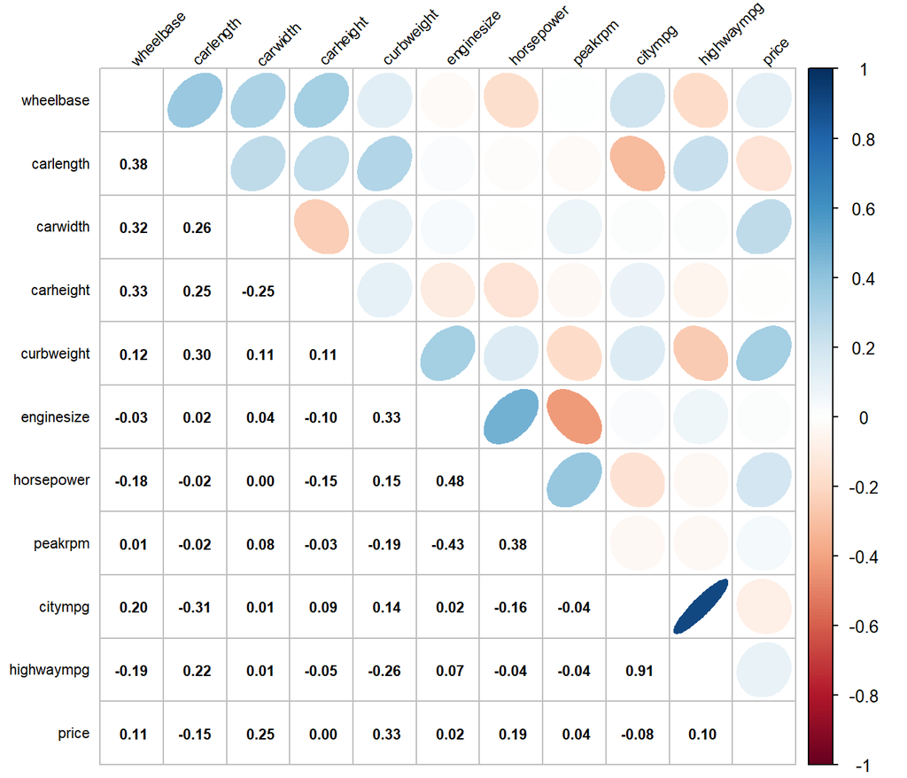

```r
corrplot.mixed(round(cor_p$estimate, 4), lower.col = 'black', upper = 'ellipse', number.cex = 0.7, tl.pos = 'lt', tl.cex = 0.7, tl.col = 'black', tl.srt = 45)
```

Проинтерпретируем результаты:

1. Частный коэффициент корреляции меньше парного у следующих переменных: carlength и wheelbase (0,38 < 0,86), enginesize и curbweight (0,33 < 0,84), horsepower и enginesize (0,48 < 0,76) и так далее. Следовательно, другие переменные усиливают связь между этими взаимосвязями.
2. Частный коэффициент корреляции (по модулю) становится больше парного у данных взаимосвязей: horsepower/carheight (0,15 > 0,04), citympg/carheight (0,09 > 0,08). Значит, фиксированные переменные ослабляют связь между этими взаимосвязями.
3. Также заметно, что в некоторых случаях (например, price и highwaympg) частный коэффициент корреляции принимает положительное значение, в то время как парный коэффициент отрицателен, то есть зависимость между переменными изменила свое направление. Это говорит нам о том, что на данную взаимосвязь оказывают большое влияние другие переменные, и для анализа их зависимости **более корректно использовать частный коэффициент корреляции.**

### Расчёт множественного коэффициента корреляции. Проверка его значимости.

Квадрат множественного коэффициент корреляции называется множественным коэффициентом детерминации. Он характеризует долю дисперсии одной переменной (результативной), обусловленной влиянием всех остальных переменных, включенных в модель.

Раcсчитаем множественный коэффициент корреляции, который поможет нам определить тесноту линейной связи между результативной и остальными переменными:

```r
lm0 <- lm(price ~ ., df)
sqrt(summary(lm0)$r.squared)
```

```
## [1] 0.9118233
```

Полученное значение $R = 0,9118$ очень близко к 1, поэтому мы можем говорить о сильной линейной зависимости результативной переменной и всех остальных.

Теперь перейдем к поверки значимости, получившегося коэффициента:

```r
pander(summary(lm0))
```

|  | Estimate | Std. Error | t value | Pr(>\|t\|) |
| --- | --- | --- | --- | --- |
| **(Intercept)** | -67870 | 14864 | -4.566 | 8.822e-06 |
| **wheelbase** | 44.87 | 104.6 | 0.4289 | 0.6684 |
| **carlength** | -83.11 | 58.12 | -1.43 | 0.1543 |
| **carwidth** | 606.9 | 256.7 | 2.365 | 0.01904 |
| **carheight** | 236.9 | 141.3 | 1.677 | 0.09524 |
| **curbweight** | 3.916 | 1.67 | 2.345 | 0.02004 |
| **enginesize** | 100.9 | 14.13 | 7.142 | 1.8e-11 |
| **horsepower** | 33.05 | 16.58 | 1.994 | 0.04756 |
| **peakrpm** | 2.02 | 0.6713 | 3.008 | 0.002975 |
| **citympg** | -120.2 | 181.3 | -0.6628 | 0.5082 |
| **highwaympg** | 158.5 | 167.2 | 0.9476 | 0.3445 |

Fitting linear model: price ~ .

| Observations | Residual Std. Error | $R^2$ | Adjusted $R^2$ |
| --- | --- | --- | --- |
| 205 | 3364 | 0.8314 | 0.8227 |

Более точное значение получим при помощи функции `pf`:

```r
pf(summary(lm0)$fstatistic[1],
   summary(lm0)$fstatistic[2],
   summary(lm0)$fstatistic[3],
   lower.tail = FALSE)
```

```
##        value
## 1.966219e-69
```

P-value существенно меньше любого разумного уровня значимости. Гипотеза $H_0$ отвергается с вероятностью ошибки $a$ и коэффициент детерминации (и соответствующий множественный коэффициент корреляции) считаются значимыми.

### Регрессионный анализ. Линейная регрессионная модель.

Приступим к построению линейных регрессионных моделей

```r
corrplot.mixed(cor(df_new), lower.col = 'black', upper = 'ellipse', number.cex = 0.7, tl.pos = 'lt',
               tl.cex = 0.7, tl.col = 'black', tl.srt = 45)
```

[output not shown]

Необходимо заметить, что для некоторых объясняющих переменных парный коэффициент корреляции по модулю превышает 0,7 (например, carlength и wheelbase, carwidth и wheelbase). Это говорит нам о наличии проблемы мультиколлинеарности.

Самый простой способ преодоления этой проблемы - пересмотр набора регрессоров.

Сначала построим линейную модель множественной регрессии со всеми имеющимися в нашем распоряжении объясняющими переменными методом включения.

Идея состоит в следующем: при **методе включения** сначала строится модель с одним регрессором, для которого парный коэффициент корреляции с зависимой переменной является наибольшим по модулю. Далее добавляется следующий по тесноте линейной связи регрессор, и так до тех пор пока коэффициент при добавленном регрессоре не окажется незначимым.

```r
library(leaps)
library(questionr)
library(lmtest)
library(sjPlot)
library(tseries)
library(robustHD)
regfit_fwd <- regsubsets(price ~ ., df_new, intercept = TRUE, method = 'forward', nvmax = 10)
regfit_fwd_sum <- summary(regfit_fwd)
regfit_fwd_sum
```

```
## Subset selection object
## Call: regsubsets.formula(price ~ ., df_new, intercept = TRUE, method = "forward",
##     nvmax = 10)
## 10 Variables  (and intercept)
##            Forced in Forced out
## wheelbase      FALSE      FALSE
## carlength      FALSE      FALSE
## carwidth       FALSE      FALSE
## carheight      FALSE      FALSE
## curbweight     FALSE      FALSE
## enginesize     FALSE      FALSE
## horsepower     FALSE      FALSE
## peakrpm        FALSE      FALSE
## citympg        FALSE      FALSE
## highwaympg     FALSE      FALSE
## 1 subsets of each size up to 10
## Selection Algorithm: forward
##           wheelbase carlength carwidth carheight curbweight enginesize
## 1  ( 1 )  " "       " "       " "      " "       "*"        " "
## 2  ( 1 )  " "       " "       " "      " "       "*"        " "
## 3  ( 1 )  " "       " "       "*"      " "       "*"        " "
## 4  ( 1 )  " "       "*"       "*"      " "       "*"        " "
## 5  ( 1 )  "*"       "*"       "*"      " "       "*"        " "
## 6  ( 1 )  "*"       "*"       "*"      " "       "*"        " "
## 7  ( 1 )  "*"       "*"       "*"      " "       "*"        " "
## 8  ( 1 )  "*"       "*"       "*"      " "       "*"        " "
## 9  ( 1 )  "*"       "*"       "*"      " "       "*"        "*"
## 10  ( 1 ) "*"       "*"       "*"      "*"       "*"        "*"
##           horsepower peakrpm citympg highwaympg
## 1  ( 1 )  " "        " "     " "     " "
## 2  ( 1 )  "*"        " "     " "     " "
## 3  ( 1 )  "*"        " "     " "     " "
## 4  ( 1 )  "*"        " "     " "     " "
## 5  ( 1 )  "*"        " "     " "     " "
## 6  ( 1 )  "*"        " "     " "     "*"
## 7  ( 1 )  "*"        " "     "*"     "*"
## 8  ( 1 )  "*"        "*"     "*"     "*"
## 9  ( 1 )  "*"        "*"     "*"     "*"
## 10  ( 1 ) "*"        "*"     "*"     "*"
```

```r
names(regfit_fwd_sum)
```

```
## [1] "which"  "rsq"    "rss"    "adjr2"  "cp"     "bic"    "outmat" "obj"
```

Мы получили следующие результаты:

1. наилучшая модель с одной объясняющей переменной включает в себя переменную вес в фунтах (cubweight);
2. с двумя объясняющими переменными - вес в фунтах и лошадиные силы (curbweight and horsepower);
3. с тремя - ширина машины, вес в фунтах и лошадиные силы (carwidth, curbweight, horsepower);
4. с четырьмя - длина машины, вес в фунтах, ширина машины, лошадиные силы (carwidth, curbweight, horsepower,carlength);
5. с пятью - расстояние между передними и задними колесами, длина машины, вес в фунтах, ширина машины, лошадиные силы (carwidth, curbweight, horsepower,carlength, wheelbase);
6. с шестью - миль на галлон топлива, потребляемого при движении по шоссе, расстояние между передними и задними колесами, длина машины, вес в фунтах, ширина машины, лошадиные силы (carwidth, curbweight, horsepower,carlength, wheelbase, highway mpg);
7. с семью переменными - миль на галлон топлива, потребляемого при движении по городу, миль на галлон топлива, потребляемого при движении по шоссе, расстояние между передними и задними колесами, длина машины, вес в фунтах, ширина машины, лошадиные силы (carwidth, curbweight, horsepower,carlength, wheelbase, highway mpg, citympg);
8. восемь переменных - количество оборотов, при котором достигается максимальная мощность двигателя, миль на галлон топлива, потребляемого при движении по городу, миль на галлон топлива, потребляемого при движении по шоссе, расстояние между передними и задними колесами, длина машины, вес в фунтах, ширина машины, лошадиные силы (carwidth, curbweight, horsepower,carlength, wheelbase, highway mpg, citympg, peakrpm);
9. девять переменных - объем двигателя, количество оборотов, при котором достигается максимальная мощность двигателя, миль на галлон топлива, потребляемого при движении по городу, миль на галлон топлива, потребляемого при движении по шоссе, расстояние между передними и задними колесами, длина машины, вес в фунтах, ширина машины, лошадиные силы (carwidth, curbweight, horsepower,carlength, wheelbase, highway mpg, citympg, peakrpm, engine size).

   **Метод исключения:** сначала строится полная модель со всеми регрессорами, далее исключается регрессор с наибольшим p-value и так до тех пор, пока не останутся регрессоры, которым соответствуют значимые коэффициенты.

   На основе метода исключения мы получаем такие же модели:

```r
regfit_bwd <- regsubsets(price ~ ., df_new,  intercept = TRUE, method = 'backward',nvmax = 10 )
regfit_bwd_sum <- summary(regfit_bwd)
regfit_bwd_sum
```

```
## Subset selection object
## Call: regsubsets.formula(price ~ ., df_new, intercept = TRUE, method = "backward",
##     nvmax = 10)
## 10 Variables  (and intercept)
##            Forced in Forced out
## wheelbase      FALSE      FALSE
## carlength      FALSE      FALSE
## carwidth       FALSE      FALSE
## carheight      FALSE      FALSE
## curbweight     FALSE      FALSE
## enginesize     FALSE      FALSE
## horsepower     FALSE      FALSE
## peakrpm        FALSE      FALSE
## citympg        FALSE      FALSE
## highwaympg     FALSE      FALSE
## 1 subsets of each size up to 10
## Selection Algorithm: backward
##           wheelbase carlength carwidth carheight curbweight enginesize
## 1  ( 1 )  " "       " "       " "      " "       "*"        " "
## 2  ( 1 )  " "       " "       " "      " "       "*"        " "
## 3  ( 1 )  " "       " "       "*"      " "       "*"        " "
## 4  ( 1 )  " "       "*"       "*"      " "       "*"        " "
## 5  ( 1 )  "*"       "*"       "*"      " "       "*"        " "
## 6  ( 1 )  "*"       "*"       "*"      " "       "*"        " "
## 7  ( 1 )  "*"       "*"       "*"      " "       "*"        " "
## 8  ( 1 )  "*"       "*"       "*"      " "       "*"        " "
## 9  ( 1 )  "*"       "*"       "*"      " "       "*"        "*"
## 10  ( 1 ) "*"       "*"       "*"      "*"       "*"        "*"
##           horsepower peakrpm citympg highwaympg
## 1  ( 1 )  " "        " "     " "     " "
## 2  ( 1 )  "*"        " "     " "     " "
## 3  ( 1 )  "*"        " "     " "     " "
## 4  ( 1 )  "*"        " "     " "     " "
## 5  ( 1 )  "*"        " "     " "     " "
## 6  ( 1 )  "*"        " "     " "     "*"
## 7  ( 1 )  "*"        " "     "*"     "*"
## 8  ( 1 )  "*"        "*"     "*"     "*"
## 9  ( 1 )  "*"        "*"     "*"     "*"
## 10  ( 1 ) "*"        "*"     "*"     "*"
```

```r
names(regfit_bwd_sum)
```

```
## [1] "which"  "rsq"    "rss"    "adjr2"  "cp"     "bic"    "outmat" "obj"
```

### Выбор лучшего уравнения регрессии

#### Коэффициент детерминации

```r
res.sum <- summary(regfit_fwd_sum)
pander(data.frame(Adj.R2 = which.max(regfit_fwd_sum$adjr2)))
```

| Adj.R2 |
| --- |
| 5 |

Наибольший коэффициент детерминации у модели с пятью переменными. Он принимает значение равное 0,77084.

```r
regfit_fwd_sum$adjr2
```

```
##  [1] 0.7277928 0.7484173 0.7682233 0.7698920 0.7708430 0.7700678 0.7705724
##  [8] 0.7696655 0.7684664 0.7671784
```

#### Проверка значимости уравнения в целом и отдельных коэффициентов, проверка гипотезы о нормальном распределении случайной ошибки.

1. **Модель с одним регрессором.**

```r
lm1 <- lm(price ~ curbweight, data = df_new)
pander(summary(lm1))
```

|  | Estimate | Std. Error | t value | Pr(>\|t\|) |
| --- | --- | --- | --- | --- |
| **(Intercept)** | -12089 | 1065 | -11.35 | 4.59e-23 |
| **curbweight** | 9.515 | 0.4229 | 22.5 | 3.133e-55 |

Fitting linear model: price ~ curbweight

| Observations | Residual Std. Error | $R^2$ | Adjusted $R^2$ |
| --- | --- | --- | --- |
| 190 | 2592 | 0.7292 | 0.7278 |

Коэффициент при регрессоре значим, так как значение p-value < 0,05. Также значимо и само уравнение регрессии.

Проверим остатки на нормальность распределения.

```r
pander(shapiro.test(lm1$residuals))
```

Shapiro-Wilk normality test: `lm1$residuals`

| Test statistic | P value |
| --- | --- |
| 0.9494 | 2.838e-06 * * * |

```r
pander(jarque.bera.test(lm1$residuals))
```

Jarque Bera Test: `lm1$residuals`

| Test statistic | df | P value |
| --- | --- | --- |
| 25.79 | 2 | 2.514e-06 * * * |

Мы получили значения p-value, которые значительно меньше любого разумного уровня значимости, поэтому нулевая гипотеза о нормальности распределения остатков отвергается на уровне значимости 0,05.

Гомоскедастичность.

```r
pander(bptest(lm1))
```

studentized Breusch-Pagan test: `lm1`

| Test statistic | df | P value |
| --- | --- | --- |
| 36.95 | 1 | 1.21e-09 * * * |

Значение p-value меньше 0,05, следовательно, гомоскедастичность отсутствует.

2. **Модель с двумя переменными.**

```r
lm2 <- lm(price ~ curbweight + horsepower, data = df_new)
pander(summary(lm2))
```

|  | Estimate | Std. Error | t value | Pr(>\|t\|) |
| --- | --- | --- | --- | --- |
| **(Intercept)** | -11151 | 1050 | -10.62 | 6.538e-21 |
| **curbweight** | 7.734 | 0.5989 | 12.91 | 1.094e-27 |
| **horsepower** | 35.79 | 8.835 | 4.051 | 7.463e-05 |

Fitting linear model: price ~ curbweight + horsepower

| Observations | Residual Std. Error | $R^2$ | Adjusted $R^2$ |
| --- | --- | --- | --- |
| 190 | 2492 | 0.7511 | 0.7484 |

Уравнение регрессии значимо, его коэффициенты тоже.

```r
pander(shapiro.test(lm2$residuals))
```

Shapiro-Wilk normality test: `lm2$residuals`

| Test statistic | P value |
| --- | --- |
| 0.9371 | 2.39e-07 * * * |

```r
pander(jarque.bera.test(lm2$residuals))
```

Jarque Bera Test: `lm2$residuals`

| Test statistic | df | P value |
| --- | --- | --- |
| 35.8 | 2 | 1.686e-08 * * * |

Остатки не подчиняются нормальному закону распределения.

```r
pander(bptest(lm2))
```

studentized Breusch-Pagan test: `lm2`

| Test statistic | df | P value |
| --- | --- | --- |
| 42.95 | 2 | 4.708e-10 * * * |

Гомоскедастичность отсутствует.

3. **Модель с тремя регрессорами.**

```r
lm3 <- lm(price ~ curbweight + horsepower + carwidth, data = df_new)
pander(summary(lm3))
```

|  | Estimate | Std. Error | t value | Pr(>\|t\|) |
| --- | --- | --- | --- | --- |
| **(Intercept)** | -51819 | 9921 | -5.223 | 4.682e-07 |
| **curbweight** | 5.198 | 0.8421 | 6.173 | 4.104e-09 |
| **horsepower** | 36.99 | 8.485 | 4.359 | 2.157e-05 |
| **carwidth** | 713.6 | 173.2 | 4.121 | 5.683e-05 |

Fitting linear model: price ~ curbweight + horsepower + carwidth

| Observations | Residual Std. Error | $R^2$ | Adjusted $R^2$ |
| --- | --- | --- | --- |
| 190 | 2392 | 0.7719 | 0.7682 |

Уравнение регрессии значимо, его коэффициенты тоже.

```r
pander(shapiro.test(lm3$residuals))
```

Shapiro-Wilk normality test: `lm3$residuals`

| Test statistic | P value |
| --- | --- |
| 0.9164 | 6.434e-09 * * * |

```r
pander(jarque.bera.test(lm3$residuals))
```

Jarque Bera Test: `lm3$residuals`

| Test statistic | df | P value |
| --- | --- | --- |
| 69.33 | 2 | 8.882e-16 * * * |

Остатки не подчиняются нормальному закону распределения.

```r
pander(bptest(lm3))
```

studentized Breusch-Pagan test: `lm3`

| Test statistic | df | P value |
| --- | --- | --- |
| 28.75 | 3 | 2.524e-06 * * * |

Гомоскедастичность отсутствует.

4. **Модель с четырьмя регрессорами.**

```r
lm4 <- lm(price ~ curbweight + horsepower + carwidth + carlength, data = df_new)
pander(summary(lm4))
```

|  | Estimate | Std. Error | t value | Pr(>\|t\|) |
| --- | --- | --- | --- | --- |
| **(Intercept)** | -52005 | 9886 | -5.261 | 3.946e-07 |
| **curbweight** | 6.133 | 1.037 | 5.912 | 1.598e-08 |
| **horsepower** | 33.97 | 8.68 | 3.914 | 0.0001276 |
| **carwidth** | 824.2 | 187 | 4.407 | 1.775e-05 |
| **carlength** | -52.65 | 34.36 | -1.533 | 0.1271 |

Fitting linear model: price ~ curbweight + horsepower + carwidth + carlength

| Observations | Residual Std. Error | $R^2$ | Adjusted $R^2$ |
| --- | --- | --- | --- |
| 190 | 2383 | 0.7748 | 0.7699 |

Уравнение регрессии значимо. Коэффициент при регрессоре carlength незначим, остальные регрессоры значимы.

```r
pander(shapiro.test(lm4$residuals))
```

Shapiro-Wilk normality test: `lm4$residuals`

| Test statistic | P value |
| --- | --- |
| 0.9185 | 8.955e-09 * * * |

```r
pander(jarque.bera.test(lm4$residuals))
```

Jarque Bera Test: `lm4$residuals`

| Test statistic | df | P value |
| --- | --- | --- |
| 72.22 | 2 | 2.22e-16 * * * |

Остатки не подчиняются нормальному закону распределения.

```r
pander(bptest(lm4))
```

studentized Breusch-Pagan test: `lm4`

| Test statistic | df | P value |
| --- | --- | --- |
| 28.04 | 4 | 1.222e-05 * * * |

Гомоскедастичность отсутствует.

5. **Модель с пятью объясняющими переменными.**

```r
lm5 <- lm(price ~ curbweight + horsepower + carwidth + carlength + wheelbase, data = df_new)
pander(summary(lm5))
```

|  | Estimate | Std. Error | t value | Pr(>\|t\|) |
| --- | --- | --- | --- | --- |
| **(Intercept)** | -52048 | 9865 | -5.276 | 3.688e-07 |
| **curbweight** | 5.732 | 1.078 | 5.315 | 3.06e-07 |
| **horsepower** | 39.75 | 9.691 | 4.102 | 6.152e-05 |
| **carwidth** | 746.2 | 195.7 | 3.814 | 0.0001868 |
| **carlength** | -76.67 | 38.75 | -1.978 | 0.04937 |
| **wheelbase** | 99.22 | 74.62 | 1.33 | 0.1853 |

Fitting linear model: price ~ curbweight + horsepower + carwidth + carlength + wheelbase

| Observations | Residual Std. Error | $R^2$ | Adjusted $R^2$ |
| --- | --- | --- | --- |
| 190 | 2378 | 0.7769 | 0.7708 |

```r
pander(shapiro.test(lm5$residuals))
```

Shapiro-Wilk normality test: `lm5$residuals`

| Test statistic | P value |
| --- | --- |
| 0.9252 | 2.753e-08 * * * |

```r
pander(jarque.bera.test(lm5$residuals))
```

Jarque Bera Test: `lm5$residuals`

| Test statistic | df | P value |
| --- | --- | --- |
| 63.53 | 2 | 1.599e-14 * * * |

Остатки не подчиняются нормальному закону распределения.

```r
pander(bptest(lm5))
```

studentized Breusch-Pagan test: `lm5`

| Test statistic | df | P value |
| --- | --- | --- |
| 32.54 | 5 | 4.647e-06 * * * |

Гомоскедастичность отсутствует.

6. **Модель с шестью объясняющими переменными.**

```r
lm6 <- lm(price ~ curbweight + horsepower + carwidth + carlength + wheelbase + highwaympg, data = df_new)
pander(summary(lm6))
```

|  | Estimate | Std. Error | t value | Pr(>\|t\|) |
| --- | --- | --- | --- | --- |
| **(Intercept)** | -53790 | 10278 | -5.233 | 4.531e-07 |
| **curbweight** | 5.832 | 1.092 | 5.339 | 2.748e-07 |
| **horsepower** | 43.47 | 11.43 | 3.802 | 0.0001951 |
| **carwidth** | 738.9 | 196.4 | 3.763 | 0.0002257 |
| **carlength** | -72.92 | 39.29 | -1.856 | 0.06507 |
| **wheelbase** | 99.06 | 74.75 | 1.325 | 0.1867 |
| **highwaympg** | 30.95 | 50.23 | 0.6161 | 0.5386 |

Fitting linear model: price ~ curbweight + horsepower + carwidth + carlength + wheelbase + highwaympg

| Observations | Residual Std. Error | $R^2$ | Adjusted $R^2$ |
| --- | --- | --- | --- |
| 190 | 2382 | 0.7774 | 0.7701 |

Уравнение регрессии значимо. Коэффициенты при регрессорах carlength, wheelbase, highwaympg незначимы.

```r
pander(shapiro.test(lm6$residuals))
```

Shapiro-Wilk normality test: `lm6$residuals`

| Test statistic | P value |
| --- | --- |
| 0.9247 | 2.521e-08 * * * |

```r
pander(jarque.bera.test(lm6$residuals))
```

Jarque Bera Test: `lm6$residuals`

| Test statistic | df | P value |
| --- | --- | --- |
| 63.67 | 2 | 1.499e-14 * * * |

Остатки не подчиняются нормальному закону распределения.

```r
pander(bptest(lm6))
```

studentized Breusch-Pagan test: `lm6`

| Test statistic | df | P value |
| --- | --- | --- |
| 32.65 | 6 | 1.226e-05 * * * |

Гомоскедастичность отсутствует.

7. **Модель с семью переменными.**

```r
lm7 <- lm(price ~ curbweight + horsepower + carwidth + carlength + wheelbase + highwaympg + citympg, data = df_new)
pander(summary(lm7))
```

|  | Estimate | Std. Error | t value | Pr(>\|t\|) |
| --- | --- | --- | --- | --- |
| **(Intercept)** | -53486 | 10270 | -5.208 | 5.132e-07 |
| **curbweight** | 6.076 | 1.11 | 5.472 | 1.459e-07 |
| **horsepower** | 40.18 | 11.75 | 3.418 | 0.0007776 |
| **carwidth** | 730.7 | 196.3 | 3.723 | 0.0002622 |
| **carlength** | -87.06 | 41.02 | -2.122 | 0.03518 |
| **wheelbase** | 120.7 | 76.87 | 1.57 | 0.1181 |
| **highwaympg** | 167.1 | 125.4 | 1.332 | 0.1845 |
| **citympg** | -155.1 | 131 | -1.184 | 0.2378 |

Fitting linear model: price ~ curbweight + horsepower + carwidth + carlength + wheelbase + highwaympg + citympg

| Observations | Residual Std. Error | $R^2$ | Adjusted $R^2$ |
| --- | --- | --- | --- |
| 190 | 2380 | 0.7791 | 0.7706 |

Уравнение регрессии значимо. Коэффициента при регрессорах wheelbase, highwaympg, citympg, незначимы на уровне значимости 0,05. Остальные коэффициенты значимы.

```r
pander(shapiro.test(lm7$residuals))
```

Shapiro-Wilk normality test: `lm7$residuals`

| Test statistic | P value |
| --- | --- |
| 0.9316 | 8.539e-08 * * * |

```r
pander(jarque.bera.test(lm7$residuals))
```

Jarque Bera Test: `lm7$residuals`

| Test statistic | df | P value |
| --- | --- | --- |
| 56.88 | 2 | 4.461e-13 * * * |

Остатки не подчиняются нормальному закону распределения.

```r
pander(bptest(lm7))
```

studentized Breusch-Pagan test: `lm7`

| Test statistic | df | P value |
| --- | --- | --- |
| 34.75 | 7 | 1.244e-05 * * * |

Гомоскедастичность отсутствует.

8. **Модель с восемью регрессорами**

```r
lm8 <- lm(price ~ curbweight + horsepower + carwidth + carlength + wheelbase + highwaympg + citympg + peakrpm, data = df_new)
pander(summary(lm8))
```

|  | Estimate | Std. Error | t value | Pr(>\|t\|) |
| --- | --- | --- | --- | --- |
| **(Intercept)** | -54929 | 10642 | -5.162 | 6.397e-07 |
| **curbweight** | 6.337 | 1.216 | 5.212 | 5.057e-07 |
| **horsepower** | 38.6 | 12.14 | 3.178 | 0.001743 |
| **carwidth** | 722.1 | 197.3 | 3.66 | 0.0003307 |
| **carlength** | -86.17 | 41.14 | -2.095 | 0.03759 |
| **wheelbase** | 119.3 | 77.07 | 1.548 | 0.1233 |
| **highwaympg** | 172.1 | 126 | 1.365 | 0.1739 |
| **citympg** | -151.4 | 131.4 | -1.152 | 0.2507 |
| **peakrpm** | 0.2424 | 0.4554 | 0.5324 | 0.5951 |

Fitting linear model: price ~ curbweight + horsepower + carwidth + carlength + wheelbase + highwaympg + citympg + peakrpm

| Observations | Residual Std. Error | $R^2$ | Adjusted $R^2$ |
| --- | --- | --- | --- |
| 190 | 2385 | 0.7794 | 0.7697 |

Уравнение регрессии значимо. Коэффициенты при регрессорах wheelbase, highwaympg, citympg, peakrpm незначимы. Остальные коэффициенты значимы.

```r
pander(shapiro.test(lm8$residuals))
```

Shapiro-Wilk normality test: `lm8$residuals`

| Test statistic | P value |
| --- | --- |
| 0.9283 | 4.77e-08 * * * |

```r
pander(jarque.bera.test(lm8$residuals))
```

Jarque Bera Test: `lm8$residuals`

| Test statistic | df | P value |
| --- | --- | --- |
| 64.5 | 2 | 9.881e-15 * * * |

Остатки не подчиняются нормальному закону распределения.

```r
pander(bptest(lm8))
```

studentized Breusch-Pagan test: `lm8`

| Test statistic | df | P value |
| --- | --- | --- |
| 39.06 | 8 | 4.798e-06 * * * |

Гомоскедастичность отсутствует.

9. **Модель с девятью регрессорами**

```r
lm9 <- lm(price ~ curbweight + horsepower + carwidth + carlength + wheelbase + highwaympg + citympg + peakrpm + enginesize, data = df_new)
pander(summary(lm9))
```

|  | Estimate | Std. Error | t value | Pr(>\|t\|) |
| --- | --- | --- | --- | --- |
| **(Intercept)** | -54996 | 10672 | -5.153 | 6.695e-07 |
| **curbweight** | 6.222 | 1.302 | 4.779 | 3.646e-06 |
| **horsepower** | 36.77 | 14.21 | 2.588 | 0.01045 |
| **carwidth** | 718.5 | 198.4 | 3.622 | 0.0003798 |
| **carlength** | -86.09 | 41.25 | -2.087 | 0.03826 |
| **wheelbase** | 120.5 | 77.42 | 1.557 | 0.1212 |
| **highwaympg** | 169.7 | 126.7 | 1.339 | 0.1823 |
| **citympg** | -151.9 | 131.8 | -1.152 | 0.2507 |
| **peakrpm** | 0.2964 | 0.5049 | 0.587 | 0.558 |
| **enginesize** | 3.764 | 15.04 | 0.2502 | 0.8027 |

Fitting linear model: price ~ curbweight + horsepower + carwidth + carlength + wheelbase + highwaympg + citympg + peakrpm + enginesize

| Observations | Residual Std. Error | $R^2$ | Adjusted $R^2$ |
| --- | --- | --- | --- |
| 190 | 2391 | 0.7795 | 0.7685 |

Уравнение регрессии значимо. Коэффициенты при регрессорах wheelbase, highwaympg, citympg, peakrpm, enginesize незначимы на уровне значимости 0,05. Остальные коэффициенты значимы.

```r
pander(shapiro.test(lm9$residuals))
```

Shapiro-Wilk normality test: `lm9$residuals`

| Test statistic | P value |
| --- | --- |
| 0.9306 | 7.089e-08 * * * |

```r
pander(jarque.bera.test(lm9$residuals))
```

Jarque Bera Test: `lm9$residuals`

| Test statistic | df | P value |
| --- | --- | --- |
| 60.91 | 2 | 5.951e-14 * * * |

Остатки не подчиняются нормальному закону распределения.

```r
pander(bptest(lm9))
```

studentized Breusch-Pagan test: `lm9`

| Test statistic | df | P value |
| --- | --- | --- |
| 46.63 | 9 | 4.594e-07 * * * |

Гомоскедастичность отсутствует.

10. Модель с десятью регрессорами

```r
lm10 <- lm(price ~ ., data = df_new)
pander(summary(lm10))
```

|  | Estimate | Std. Error | t value | Pr(>\|t\|) |
| --- | --- | --- | --- | --- |
| **(Intercept)** | -54689 | 11702 | -4.673 | 5.806e-06 |
| **wheelbase** | 122.3 | 82.4 | 1.485 | 0.1394 |
| **carlength** | -85.4 | 42.73 | -1.999 | 0.04716 |
| **carwidth** | 715.1 | 205.9 | 3.473 | 0.0006443 |
| **carheight** | -7.03 | 108.3 | -0.06488 | 0.9483 |
| **curbweight** | 6.232 | 1.314 | 4.742 | 4.303e-06 |
| **enginesize** | 3.664 | 15.16 | 0.2417 | 0.8093 |
| **horsepower** | 36.63 | 14.41 | 2.542 | 0.01188 |
| **peakrpm** | 0.2954 | 0.5066 | 0.5831 | 0.5606 |
| **citympg** | -151.1 | 132.7 | -1.139 | 0.2564 |
| **highwaympg** | 169.3 | 127.2 | 1.33 | 0.1852 |

Fitting linear model: price ~ .

| Observations | Residual Std. Error | $R^2$ | Adjusted $R^2$ |
| --- | --- | --- | --- |
| 190 | 2397 | 0.7795 | 0.7672 |

Уравнение регрессии значимо. Коэффициенты при регрессорах wheelbase, carheight, enginesize, peakrpm, citympg, highwaympg незначимы на уровне значимости 0,05. Остальные коэффициенты значимы.

```r
pander(shapiro.test(lm10$residuals))
```

Shapiro-Wilk normality test: `lm10$residuals`

| Test statistic | P value |
| --- | --- |
| 0.9309 | 7.507e-08 * * * |

```r
pander(jarque.bera.test(lm10$residuals))
```

Jarque Bera Test: `lm10$residuals`

| Test statistic | df | P value |
| --- | --- | --- |
| 60.72 | 2 | 6.517e-14 * * * |

Остатки не подчиняются нормальному закону распределения.

```r
pander(bptest(lm10))
```

studentized Breusch-Pagan test: `lm10`

| Test statistic | df | P value |
| --- | --- | --- |
| 46.97 | 10 | 9.578e-07 * * * |

Гомоскедастичность отсутствует.

Таким образом, лучшим уравнением регрессии из проанализированных является уравнение с пятью переменными (lm_5), так как у него самый высокий скорректированный коэффициент детерминации. Но остатки этой модели не подчиняются нормальному закону распределения (аналогичная ситуация наблюдается и у других линейных моделей), также отсутствует гомоскедастичность ( у других моделей тоже). Само уравнение значимо, и считается, что все объясняющие переменные полезны для объяснения вариаций в цене . Коэффициент при одном из регрессоров незначим.